# AI Computer Assignment 4

## Name: Sepehr Ahmadi

## Student Id: 810897031

#### Spring 1400

```python
%%html
<style>.text_cell .rendered_html * {direction: rtl; text-align: right;}</style>
```

```python
from __future__ import unicode_literals
from hazm import *
import numpy as np
import pandas as pd
import time
import sklearn as sk
```

## سوال ۱:

این نمودار به ما اجازه میدهد که فیچرهای مهم را که در شناسایی کلاس قیمت میتواند بما کمک کند، را بیابیم و در فرایند classification از آنها استفاده کنیم.

**کارهای انجام شده در preprocessing**:

- در کتگوری مقادیر Nan با ۱ یعنی خودروی سبک عوض شده است.
- در برند به Nan مقدار ٬سایر٬ داده شده است.
- در mileage مقادیر Nan با میانگین ستون جایگزین شده اند.
- از year مقادیر string با int جایگزین شدند.
- دیتافریم اصلی به دو بخش test و train تقسیم شده است. -ستون های title و description با هم ترکیب شده و با استفاده از توابع کتابخانه هضم، نرمالیزه شده است.
- متن های بدست آمده بوسیله CountVectorizer و tf-idf به فیچر تبدیل شده؛ به اینگونه که 30 پرتکرارترین کلمات هر کدام ستونی بخود اختصاص میدهند. سپس با دیتافریم train آنها را ترکیب میکنیم.

## سوال ۲:

از روش label_encoding() برای brand و category استفاده کرده ام.

با وجود اینکه روش one hot encoding بنظر میرسد برای داده هایی با مقادیر گسسته که مقدار لیبل شده آنها لزوما نشاندهنده برتری نسبت به لیبل دیگر نیست، بهتر میباشد، اما در اینجا به علت تعدد مقادیر برند(۲۵)، در صورت استفاده از این روش نیاز به اضافه کردن ۲۵ ستون دیگر داریم. اینکار موجب سنگین شده دیتافریم و بزرگ شدن بیش از حد پردازش شود که ممکن است ما را با ارور مموری مواجه کند. همچنین مشاهده شد که با استفاده از این روش تغییر قابل ملاحظه ای در rmse بدست آمده ایجاد نشده. البته linear Regression نسبتا بیشتر از بقیه روشها پیشرفت میکند.

از طرف دیگر، کتگوری تنها تشکیل شده از دو مقدار است. یعنی به نوعی باینری است و استفاده از one hot معنای چندانی به داده ها اضافه نمیکند.

## سوال ۳:

در این پیاده سازی از tf-idf استفاده شده است. تعداد کلمات استخراج شده بعنوان فیچر نیز ۳۰تا در نظر گرفته شده است که عملکرد مناسبی از این تعداد مشاهده شده است.

tf-idf نتیجه نسبتا بهتری تسبت به countVectorizer داشته است. با وجود اینکه کلمات پر تکرار اکثرا با استفاده از stopwordها حذف شده اند، اما این روش این فرایند را کامل کرده و همچنین داده های نرمالیزه شده به ما تحویل میدهد.

تعداد کلمات ۳۰تا نتیجه مطلوبتری داشته و بیشتر از این مقدار با وجود پیچیده تر کردن دیتافری، تاثیر چشمگیری در نتیجه هیچ یک از روش ها نداشته است. مقادیر کمتر هم موجب افت نتیجه شده بودند.

## سوال ۴:

- روش ۱: حذف کردن ردیف داده
- روش ۲: پر کردن آن با مقادیر میانه یا میانگین
- روش ۳: پر کردن داده های دسته ای با پرتکرارترین دسته

مقادیر حذف شده برای ستون قیمت را حذف میکنیم. چرا که اطلاعات موجود در ستونهای دیگر ردیفهای حذف شده به ما کمکی در مشخص کردن خود قیمت که از ردیف حذف شده نخواهد کرد.

اما ستونهای دیگر که مقادیر حذف شده داشتند، سعی بر جایگزین کردن آنها بود، چرا که از ستونهای دیگر میتوان اطلاعاتی برای کامل کردن مدل classification بدست آورد:

- برند: با ٬سایر٬ پر شده است.
- کتگوری: با ۱ یا 'light' جایگزین کردیم چرا که اکثر خودروها سبکن و اختمال درست بودن بیشتر است.
- mileage: با میانگین ستون پر شده است.

## سوال ۵:

داده ها بصورت ۹۰٪ برای train به ۱۰٪ برای تست تقسیم شده اند. چرا که طی آزمون و خطا، مطلوبترین نتیجه را ایتن تقسیم بندی داشته است.

برای ۹۸٪، rmse برای linear regression خطای بیشتری (حدود یک میلیون) داشته است.

برای ۴۰٪ نیز همین نتیجه مشاهده شد.

این پدیده ها به ترتیب overfitting و underfitting نام دارند.

overfitting زمانی رخ میدهد که داده های یادگیری طوری زیاد باشند که مدل بتواند برای همان داده ها فقط پاسخ مناسب داشته باشد.

underfitting برعکس است و نمیتواند برای داده های یادگیری هم پاسخ مطلوب داشته باشد.

## سوال ۶:

در حالت اول، به یک مقدار ثابت میل میکند (حدود ۲۴ میلیون). در حالت دوم خطا بسیار زیاد میشود.

با تحلیل نمودار مشاهده میشود که هر چقدر عمق بیشتر شود لزوما مدل بهتری بدست نمی آوریم و مقدار مطلوب لازم است که جستوجو شود. در اینجا حدود ۱۲ میباشد.

## سوال ۷:

نتیجه مدل Random Forest بسیار مطلوبتر است.

بنظر میرسد که variance در decision tree بیشتر است. چرا که تعداد فیچرها در مدل زیاد است و decision tree همه ی آنها را باید در نظر بگیر.

در حالی که در Random Forest چون فیچرها چند سری محدود و رندم انتخاب شده و مقایسه میشوند، در نتیجه مدل واریانس کمتر و bias بیشتر خواهد داشت. در اینجا هم چون به یک compromise نسبی در بین این دو در این مدل رسیدیم، بنابراین طبق پیش بینی عملکرد این مدل بهتر است.

```python
df = pd.read_csv('data/data/vehicles.csv')
# df1.head(10)
cat = {}
words_dict = {}
stop_words1 = ['.',',','«','»','(',')','،','[',']','{','}','-','','؛',':']
stop_words2 = {stopword : 0 for stopword in stopwords_list()}

df.drop(df[df['price'] == -1].index, inplace = True)
le = sk.preprocessing.LabelEncoder()
df['category'].fillna(1, inplace=True)
df['brand'].fillna("سایر", inplace=True)

df['category'] = le.fit_transform(df['category'])
df['brand'] = le.fit_transform(df['brand'])
df['mileage'].fillna(round(df['mileage'].mean()), inplace=True)

df['year'] = df['year'].replace({'<1366' : 1366})
df['year'] = df['year'].astype(float)
df['year'].fillna(round(df['year'].mean()), inplace=True)
df['year'] = df['year'].astype(int)
df.reset_index(inplace = True)
df.drop('index', axis = 1,inplace = True)

# df_train, df_test = sk.model_selection.train_test_split(df, test_size = 0.3, shuffle = False)
tot_num_rows = len(df)
split_row = round(0.9*tot_num_rows)
df_train = df.iloc[:split_row,:]
df_test = df.iloc[split_row+1:,:]
df_test.index = np.arange(0, len(df_test))
```

```python
normalizer = Normalizer()
stemmer = Stemmer()

df_train_desc = df_train['title']+ ' ' + df_train['description']

normalizer = Normalizer()
stemmer = Stemmer()
lemmatizer = Lemmatizer()

for i,data in df_train_desc.items():
    title_str = normalizer.normalize(data)
    title = word_tokenize(title_str)
    str_out = ""
    for word in title:
        if word in stop_words1 or word in stop_words2:
            continue

        stemmed_word = stemmer.stem(word)
        if stemmed_word in stop_words1 or stemmed_word in stop_words2:
            continue

        clean_word = lemmatizer.lemmatize(stemmed_word)
        if clean_word in stop_words1 or clean_word in stop_words2:
            continue
        str_out += clean_word + " "
    df_train_desc[i] = str_out

# df_train_desc
```

```python
from sklearn.feature_extraction.text import (CountVectorizer,
                                             TfidfVectorizer,
                                             TfidfTransformer)

vectorizer = CountVectorizer(ngram_range=(1, 1), max_features=30)
count_vectorized = vectorizer.fit_transform(df_train_desc)
tfidf_transformer = TfidfTransformer(smooth_idf=True, use_idf=True)
vectorized = tfidf_transformer.fit_transform(count_vectorized)
# vectorized = vectorizer.fit_transform(df_train_desc)
df_desc = pd.DataFrame(vectorized.toarray(),
            columns=vectorizer.get_feature_names())
vocab = vectorizer.get_feature_names()
# df_desc
```

```python
from sklearn.feature_selection import mutual_info_regression
from sklearn.feature_extraction.text import (CountVectorizer, TfidfVectorizer, TfidfTransformer)
X = df_train.drop(['price','created_at','description', 'title'], axis = 1)
X = X.join(df_desc)
y = df_train['price']
```

```python
mi = mutual_info_regression(X,y)
# mi
```

```python
mi = pd.Series(mi)
mi.index = X.columns
mi.sort_values(ascending = False, inplace=True)
# mi[:15]
# mi
```

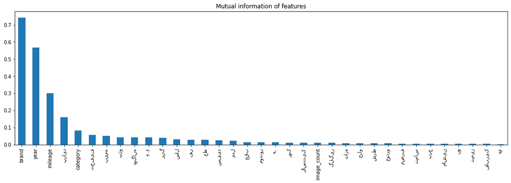

```python
import matplotlib.pyplot as plt
plt.title('Mutual information of features')
mi.plot.bar(figsize=(18,5))
plt.show()
```

```python
normalizer = Normalizer()
stemmer = Stemmer()

df_test_desc = df_test['title']+ ' ' + df_test['description']

normalizer = Normalizer()
stemmer = Stemmer()
lemmatizer = Lemmatizer()

for i,data in df_test_desc.items():
    title_str = normalizer.normalize(data)
    title = word_tokenize(title_str)
    str_out = ""
    for word in title:
        if word in stop_words1 or word in stop_words2:
            continue

        stemmed_word = stemmer.stem(word)
        if stemmed_word in stop_words1 or stemmed_word in stop_words2:
            continue

        clean_word = lemmatizer.lemmatize(stemmed_word)
        if clean_word in stop_words1 or clean_word in stop_words2:
            continue
        str_out += clean_word + " "
    df_test_desc[i] = str_out

# df_test_desc
```

```python
vectorizer = CountVectorizer(ngram_range=(1, 1), max_features=20, vocabulary = vocab)
count_vectorized = vectorizer.fit_transform(df_test_desc)
tfidf_transformer = TfidfTransformer(smooth_idf=True, use_idf=True)
vectorized = tfidf_transformer.fit_transform(count_vectorized)
# vectorized = vectorizer.fit_transform(df_test_desc)
df_test_desc = pd.DataFrame(vectorized.toarray(),
            columns=vectorizer.get_feature_names())
# df_test_desc
```

```python
X_test = df_test.drop(['price','created_at','description', 'title'], axis = 1)
# X = X.drop(list(mi[10:].index), axis = 1)
X_test = X_test.join(df_test_desc)
# X_test = X_test.drop(mi[10:].index, axis = 1)
y_test = df_test['price']
```

```python
############# KNN
from sklearn.neighbors import KNeighborsClassifier
from sklearn.metrics import mean_squared_error
k = 10
knn = KNeighborsClassifier(n_neighbors = 100, algorithm = 'kd_tree')
knn.fit(X,y)
y_pred_knn = knn.predict(X_test)
rmse = mean_squared_error(y_test, y_pred_knn, squared = False)
print('RMSE is: ', rmse)
print('MSE is: ', rmse*rmse)
```

```
RMSE is:  24913339.738561686
MSE is:  620674496928996.9
```

```python
#############Linear Regression
from sklearn.linear_model import LinearRegression
lm = LinearRegression()
lm.fit(X, y)
y_pred_lm = lm.predict(X_test)
rmse = mean_squared_error(y_test, y_pred_lm, squared = False)
print('RMSE is: ', rmse)
print('MSE is: ', rmse*rmse)
```

```
RMSE is:  21234338.637318607
MSE is:  450897137364321.9
```

```python
#############Decision Tree
from sklearn.tree import DecisionTreeClassifier

dt = DecisionTreeClassifier(max_depth = 12, min_samples_split = 10, criterion = "entropy")
dt.fit(X,y)
y_pred_dt = dt.predict(X_test)
rmse = mean_squared_error(y_test, y_pred_dt, squared = False)
print('RMSE is: ', rmse)
print('MSE is: ', rmse*rmse)
```

```
RMSE is:  17491328.143481884
MSE is:  305946560222961.44
```

```python
from sklearn.tree import DecisionTreeClassifier
rmse_dt = []
mse_dt = []
# count = 0
for depth in range(3,25,3):
    dt = DecisionTreeClassifier(max_depth = depth, min_samples_split = 10, criterion = "entropy")
    dt.fit(X,y)
    y_pred_dt = dt.predict(X_test)
    rmse_dt.append(mean_squared_error(y_test, y_pred_dt, squared = False))
    mse_dt.append(rmse_dt[count]*rmse_dt[count])
```

```python
rmse_dt
```

```
[30567962.163294546,
 26049653.563738585,
 23567960.760341186,
 21431390.13972565,
 23331577.062319174,
 24038221.60251945,
 24276945.90037952,
 24046109.485181447]
```

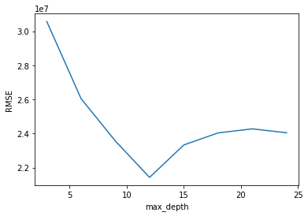

```python
plt.plot(range(3,25,3), rmse_dt)
plt.ylabel('RMSE')
plt.xlabel('max_depth')
plt.show()
```

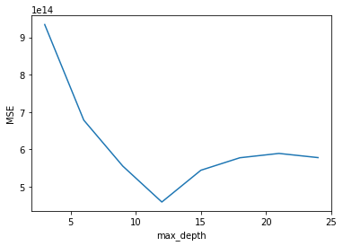

```python
mse_dt = [i*i for i in rmse_dt]
plt.plot(range(3,25,3), mse_dt)
plt.ylabel('MSE')
plt.xlabel('max_depth')
plt.show()
```

```python
#############Random Forest
from sklearn.preprocessing import StandardScaler
from sklearn.ensemble import RandomForestRegressor
# sc = StandardScaler()
# X = sc.fit_transform(X)
# X_test = sc.transform(X_test)
regressor = RandomForestRegressor(n_estimators=50, max_depth = 12, min_samples_split = 10,
                                  random_state = 0)
regressor.fit(X, y)
y_pred_rfg = regressor.predict(X_test)
rmse = mean_squared_error(y_test, y_pred_rfg, squared = False)
print('RMSE is: ', rmse)
print('MSE is: ', rmse*rmse)
```

```
RMSE is:  11952547.759099707
MSE is:  142863397933559.44
```